# An introduction to the regressinator

### Categorical predictors

R supports many common probability distributions, so most common predictor variable distributions can be specified. But categorical predictor variables (factors) are very common in practice, and so the regressinator provides `rfactor()` for drawing factor variables:

```r
# default is equally likely levels
rfactor(5, c("foo", "bar", "baz"))
```

```
#> [1] baz bar bar baz bar
#> Levels: foo bar baz
```

```r
# but probabilities per level can be specified
rfactor(5, c("foo", "bar", "baz"), c(0.4, 0.3, 0.3))
```

```
#> [1] baz foo foo bar baz
#> Levels: foo bar baz
```

Then, using the `by_level()` helper, we can use factors in defining a regression model. For instance, here is a model with a different intercept per group:

```r
intercepts <- c("foo" = 2, "bar" = 30, "baz" = 7)

factor_intercept_pop <- population(
  group = predictor(rfactor,
                    levels = c("foo", "bar", "baz"),
                    prob = c(0.1, 0.6, 0.3)),
  x = predictor(runif, min = 0, max = 10),
  y = response(by_level(group, intercepts) + 0.3 * x,
               error_scale = 1.5)
)
```

Or, similarly, a model with a different slope per group:

```r
slopes <- c("foo" = 2, "bar" = 30, "baz" = 7)

factor_slope_pop <- population(
  group = predictor(rfactor,
                    levels = c("foo", "bar", "baz"),
                    prob = c(0.1, 0.6, 0.3)),
  x = predictor(runif, min = 0, max = 10),
  y = response(7 + by_level(group, slopes) * x,
               error_scale = 1.5)
)
```

## Sampling from the population

We can use `sample_x()` to get a sample from a population. `sample_y()` then works on this sample and adds a `y` column, following the relationship specified in the population.

```r
linear_samp <- sample_y(sample_x(linear_pop, n = 10))
```

Sampling X and Y is separated because often, in regression theory, we treat X as fixed – hence we want to conduct simulations where the same X data is used and we repeatedly draw new Y values according to the population relationship.

We can also use R pipes to put together simulations:

```r
logistic_pop |>
  sample_x(n = 10) |>
  sample_y()
```

```
#> Sample of 10 observations from
#> Population with variables:
#> x1: rnorm(list(mean = 0, sd = 10))
#> x2: runif(list(min = 0, max = 10))
#> y: binomial(0.7 + 2.2 * x1 - 0.2 * x2, size = 1L)
#>
#> # A tibble: 10 × 3
#>        x1    x2     y
#>     <dbl> <dbl> <int>
#>  1   2.92 6.45      1
#>  2  20.1  1.29      1
#>  3   7.53 5.60      1
#>  4  -2.55 7.58      0
#>  5 -10.0  0.644     0
#>  6  -4.77 2.74      0
#>  7   9.82 9.02      1
#>  8  -5.57 3.50      0
#>  9 -12.0  3.97      0
#> 10 -13.3  5.15      0
```

The object this produces is a standard data frame (just with a few extra attributes), so it can be given to `lm()`, `glm()`, or any other standard modeling function that uses data frames.

## Fitting models

After we simulate a sample from a population, we can fit our chosen models to that sample. That model may simply use the predictors as-is, entering them into the design matrix and obtaining estimates through least square or maximum likelihood. But it is also common to represent the predictors differently in the model:

- Factor predictors are typically represented as several columns, for instance with one-hot encoding
- Predictors might be transformed, so the transformed version enters the model
- To fit a polynomial or spline, we might use several transformations of the predictor in the model (such as linear, squared, and cubed terms)

We call these transformed and recoded variables *regressors*. The coefficients of a model give the relationship between the *regressors* and the response, but the regressors may be transformed versions of the predictors. Many conventional diagnostics are based on the regressors, such as most residual plots, but as we will see below, others directly examine the relationship between the predictors and the response, however those predictors have been transformed and entered into the model.

We can, in principle, do almost any regression we desire. The only constraint is that we must use the `data` argument to our modeling function (such as `lm()` or `glm()`) to provide the data. That is, we must do this:

```r
fit <- lm(y ~ x1 + x2, data = linear_samp)
```

But **not** this:

```r
fit <- lm(linear_samp$y ~ linear_samp$x1 + linear_samp$x2)
```

Using the `data` argument allows the regressinator to conduct simulations by passing new data in that argument; if you don’t use it and refer to your local environment, there’s no reliable way to change the data in your model. The relevant functions will automatically detect models without a `data` argument and complain.

## Producing diagnostics

Once we have a sample and fit a model, we can conduct diagnostics. Simple diagnostic plots can easily be made using `broom::augment()`, which generates a data frame with columns including the predictors, residuals, standardized residuals, fitted value, and other useful statistics for each observation. It also works for many common types of models; see the [broom documentation](https://broom.tidymodels.org/) for details.

For example, consider a simple dataset where the true relationship between `x1` and `y` is not linear. We can quickly plot residuals versus fitted values:

```r
library(broom)

nonlinear_pop <- population(
  x1 = predictor(runif, min = 1, max = 8),
  x2 = predictor(runif, min = 0, max = 10),
  y = response(0.7 + x1**2 - x2, family = gaussian(),
               error_scale = 4.0)
)

nonlinear_data <- nonlinear_pop |>
  sample_x(n = 100) |>
  sample_y()

nonlinear_fit <- lm(y ~ x1 + x2, data = nonlinear_data)

# to see the kind of information we get from an augmented fit
augment(nonlinear_fit)
```

```
#> # A tibble: 100 × 9
#>        y    x1     x2 .fitted .resid   .hat .sigma   .cooksd .std.resid
#>    <dbl> <dbl>  <dbl>   <dbl>  <dbl>  <dbl>  <dbl>     <dbl>      <dbl>
#>  1 14.4   3.42 1.35     14.2   0.219 0.0316   4.36 0.0000287     0.0513
#>  2  5.68  2.69 5.75      2.46  3.22  0.0186   4.34 0.00355       0.750
#>  3 12.9   4.30 4.76     18.3  -5.45  0.0102   4.32 0.00552      -1.26
#>  4 21.6   4.32 5.45     17.7   3.91  0.0107   4.34 0.00296       0.908
#>  5 -1.92  1.17 6.35    -12.2  10.3   0.0371   4.22 0.0747        2.41
#>  6 31.9   6.51 8.27     34.5  -2.65  0.0361   4.35 0.00484      -0.623
#>  7 32.4   5.77 0.0692   37.2  -4.79  0.0432   4.33 0.0192       -1.13
#>  8 11.2   3.99 4.18     16.1  -4.84  0.0116   4.33 0.00495      -1.12
#>  9 30.2   6.31 7.08     34.0  -3.84  0.0242   4.34 0.00665      -0.897
#> 10 15.7   4.47 6.73     17.6  -1.90  0.0150   4.35 0.000986     -0.442
#> # ℹ 90 more rows
```

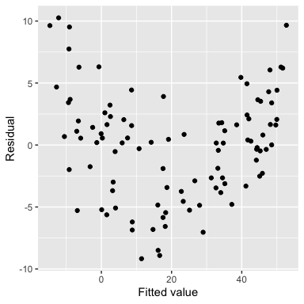

```r
library(ggplot2)

ggplot(augment(nonlinear_fit),
       aes(x = .fitted, y = .resid)) +
  geom_point() +
  labs(x = "Fitted value", y = "Residual")
```

The regressinator builds on these tools to support additional diagnostics. For example, `augment_longer()` is like `broom::augment()`, but produces one row per predictor per observation, essentially putting the data in “long” format. This makes it easy to facet the data to plot residuals against each predictor:

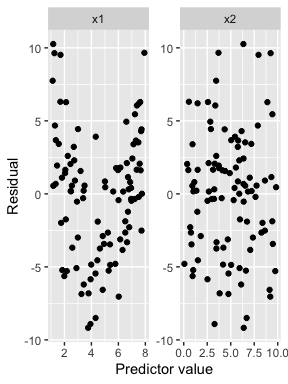

```r
ggplot(augment_longer(nonlinear_fit),
       aes(x = .predictor_value, y = .resid)) +
  geom_point() +
  facet_wrap(vars(.predictor_name), scales = "free") +
  labs(x = "Predictor value", y = "Residual")
```

Partial residuals are an extension of ordinary residuals that are defined in terms of each original predictor; we can think of a partial residual plot for a particular predictor as showing the relationship between that predictor and the response, after “adjusting for” the other predictors according to our fitted model. The `partial_residuals()` function calculates partial residuals in tidy format, and its documentation provides detailed references on the use and interpretation of partial residuals.

Here the black line gives the fitted predictor effects (i.e., the model estimate of the relationship), while the blue line smooths the partial residuals. We can see that for `x1`, the blue line deviates systematically from the black line in a quadratic shape:

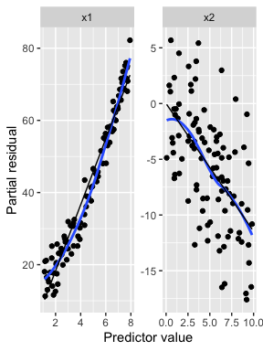

```r
ggplot(partial_residuals(nonlinear_fit),
       aes(x = .predictor_value, y = .partial_resid)) +
  geom_point() + # partial residuals
  geom_smooth(se = FALSE) + # smoothed residuals
  geom_line(aes(x = .predictor_value, y = .predictor_effect)) + # effects
  facet_wrap(vars(.predictor_name), scales = "free") +
  labs(x = "Predictor value", y = "Partial residual")
```

If we fit a quadratic model for `x1`, the partial residuals reflect this. The black line for the effect of `x1` is now quadratic, and the partial residuals closely follow it:

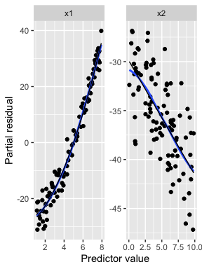

```r
quadratic_fit <- lm(y ~ poly(x1, 2) + x2, data = nonlinear_data)

ggplot(partial_residuals(quadratic_fit),
       aes(x = .predictor_value, y = .partial_resid)) +
  geom_point() + # partial residuals
  geom_smooth(se = FALSE) + # smoothed residuals
  geom_line(aes(x = .predictor_value, y = .predictor_effect)) + # effects
  facet_wrap(vars(.predictor_name), scales = "free") +
  labs(x = "Predictor value", y = "Partial residual")
```

These diagnostic functions work for linear models and also GLMs fit by `glm()`. See `vignette("linear-regression-diagnostics")` and `vignette("logistic-regression-diagnostics")` for further diagnostic examples.

## Visual inference

It can be difficult to tell whether a particular pattern in model diagnostics signifies a real problem or just an unlucky pattern. To help make this judgment, the regressinator provides the `model_lineup()` function. It takes a model fit and does the following:

1. Get the diagnostics from that model, using `broom::augment()` by default.
2. Simulate 19 additional datasets using the model, using the standard assumptions for that model. (For instance, for linear regression, errors are drawn from a normal distribution.) In each dataset, the same X values are used, and only new Y values are drawn. Each dataset is the same size.
3. For each of those datasets, fit the same model and calculate the diagnostics.
4. Put the diagnostics for all 20 fits into one data frame with a `.sample` column indicating which fit each diagnostic came from.
5. Print out a message indicating how to tell which of the `.sample` values comes from the original model.

This helps us compare how diagnostic plots will look when assumptions hold (by looking at the 19 simulated datasets) to how the diagnostic plots of our real model look. This visual inference approach is taken from the nullabor package.

For example, consider the same dataset where the true relationship is not linear, but we use a linear fit. We can quickly plot residuals versus fitted values:

```
#> decrypt("QUg2 qFyF Rx 8tLRyRtx Zf")
```

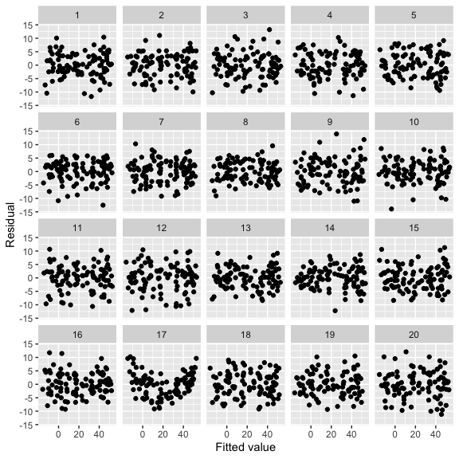

```r
model_lineup(nonlinear_fit) |>
  ggplot(aes(x = .fitted, y = .resid)) +
  geom_point() +
  facet_wrap(vars(.sample)) +
  labs(x = "Fitted value", y = "Residual")
```

The user can examine the 20 plots and guess which one represents the model fit to the original data, and which are generated assuming the fitted model is correct. The `decrypt()` code provided will print out a message indicating which of the plots is the real data; in this case, it’s the plot with the clear quadratic trend in the residuals.

This approach can be used to explore different kind of misspecification. For example, using `ols_with_error()` we can test whether we can spot non-normal residual distributions in residual Q-Q plots:

```
#> decrypt("QUg2 qFyF Rx 8tLRyRtx Zl")
```

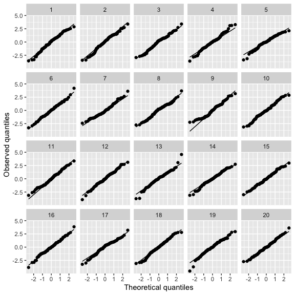

```r
heavy_tail_pop <- population(
  x1 = predictor(rnorm, mean = 5, sd = 4),
  x2 = predictor(runif, min = 0, max = 10),
  y = response(
    4 + 2 * x1 - 3 * x2,
    family = ols_with_error(rt, df = 3),
    error_scale = 1.0
  )
)

heavy_tail_sample <- heavy_tail_pop |>
  sample_x(n = 100) |>
  sample_y()

fit <- lm(y ~ x1 + x2, data = heavy_tail_sample)

model_lineup(fit) |>
  ggplot(aes(sample = .resid)) +
  geom_qq() +
  geom_qq_line() +
  facet_wrap(vars(.sample)) +
  labs(x = "Theoretical quantiles", y = "Observed quantiles")
```

Here we have Q-Q plots of residuals for a linear regression where the true relationship is linear, but the error distribution is $t_3$. This is a good way to see if we can spot the heavy-tailed distribution from among the 19 other Q-Q plots that simulate normally distributed errors.

## Sampling distributions

The `sampling_distribution()` function allows you to explore the sampling distribution of statistics and estimates from models fit to a population. Given a dataset drawn from a `population()` and a model fit to that data, it will:

1. Draw repeated samples from the population. These can be with the predictors held fixed, only resampling the response, or can be new samples of predictors and response jointly. Each sample is the same size as the original dataset.
2. For each sample, refit the model to that sample.
3. For each model fit, apply a function to get features of the model fit.
4. Combine all the results into a single data frame.

By default, the function applied to each fit is `broom::tidy()`, which can take many types of model fits and produce a data frame of the model coefficients and their standard errors.

We can hence explore the sampling distribution of estimates fit to samples from a population:

```r
d <- linear_pop |>
  sample_x(n = 30) |>
  sample_y()

fit <- lm(y ~ x1 + x2, data = d)
tidy(fit)
```

```
#> # A tibble: 3 × 5
#>   term        estimate std.error statistic  p.value
#>   <chr>          <dbl>     <dbl>     <dbl>    <dbl>
#> 1 (Intercept)    0.904    0.500       1.81 8.17e- 2
#> 2 x1             2.22     0.0241     92.1  2.85e-35
#> 3 x2            -0.289    0.0961     -3.01 5.59e- 3
```

```r
sampling_distribution(fit, d, nsim = 4)
```

```
#> # A tibble: 15 × 6
#>    term        estimate std.error statistic  p.value .sample
#>    <chr>          <dbl>     <dbl>     <dbl>    <dbl>   <dbl>
#>  1 (Intercept)    0.904    0.500       1.81 8.17e- 2       0
#>  2 x1             2.22     0.0241     92.1  2.85e-35       0
#>  3 x2            -0.289    0.0961     -3.01 5.59e- 3       0
#>  4 (Intercept)    0.741    0.509       1.46 1.57e- 1       1
#>  5 x1             2.18     0.0246     88.8  7.53e-35       1
#>  6 x2            -0.181    0.0978     -1.85 7.58e- 2       1
#>  7 (Intercept)    1.26     0.634       1.98 5.77e- 2       2
#>  8 x1             2.19     0.0306     71.5  2.52e-32       2
#>  9 x2            -0.261    0.122      -2.14 4.17e- 2       2
#> 10 (Intercept)    0.787    0.489       1.61 1.19e- 1       3
#> 11 x1             2.23     0.0236     94.6  1.38e-35       3
#> 12 x2            -0.265    0.0939     -2.83 8.75e- 3       3
#> 13 (Intercept)    1.47     0.583       2.51 1.83e- 2       4
#> 14 x1             2.22     0.0282     78.8  1.86e-33       4
#> 15 x2            -0.312    0.112      -2.78 9.75e- 3       4
```

Because the output is a tidy data frame, it’s easy to visualize the full sampling distributions:

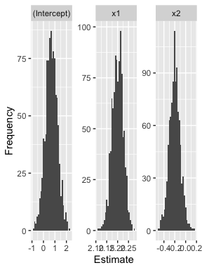

```r
samples <- sampling_distribution(fit, d, nsim = 1000)

samples |>
  ggplot(aes(x = estimate)) +
  geom_histogram() +
  facet_wrap(vars(term), scales = "free") +
  labs(x = "Estimate", y = "Frequency")
```

Or to get the mean and standard deviation of the sampling distribution:

```r
library(dplyr)

samples |>
  group_by(term) |>
  summarize(mean = mean(estimate),
            sd = sd(estimate))
```

```
#> # A tibble: 3 × 3
#>   term          mean     sd
#>   <chr>        <dbl>  <dbl>
#> 1 (Intercept)  0.695 0.521
#> 2 x1           2.20  0.0254
#> 3 x2          -0.200 0.100
```

We could use this feature to explore how sampling distributions change as we change the sample size, change the complexity of the model, or introduce various types of model misspecification.

## Parametric bootstrapping

The `parametric_boot_distribution()` function allows you to explore the distribution of statistics and estimates from models fit to data *sampled from the model fit.* Given a fitted model, it will:

1. Draw repeated samples from the model. The predictors are held fixed and the model is used to sample new response values, following the response and error distributions assumed by the model.
2. For each sample, refit a model to that sample. This could be the same model used to simulate the sample, for instance to explore diagnostics when the model is true, or an alternative model.
3. For each model fit, apply a function to get features of that model fit.
4. Combined all the results in to a single data frame.

As with `sampling_distribution()`, the default function applied to each fit is `broom::tidy()`.

This function is used by `model_lineup()` to generate the “null” diagnostics. It could also be used for hypothesis testing. For example, let’s consider the nonlinear example set up above. The data `nonlinear_data` comes from a population where the true relationship between `y` and `x1` is quadratic, but `nonlinear_fit` is a model fit with only a linear term. If we did not know a quadratic term was necessary and wanted to conduct a test, we could use an *F* test:

```r
quadratic_fit <- lm(y ~ x1 + I(x1^2) + x2, data = nonlinear_data)

anova(nonlinear_fit, quadratic_fit)
```

```
#> Analysis of Variance Table
#>
#> Model 1: y ~ x1 + x2
#> Model 2: y ~ x1 + I(x1^2) + x2
#>   Res.Df    RSS Df Sum of Sq      F    Pr(>F)
#> 1     97 1822.6
#> 2     96 1068.7  1    753.88 67.721 9.274e-13 ***
#> ---
#> Signif. codes:  0 '***' 0.001 '**' 0.01 '*' 0.05 '.' 0.1 ' ' 1
```

This suggests the quadratic term is useful, as we would expect when the true relationship is quadratic and we have an adequate sample size. But if for some reason we do not want to use an *F* test, or if we are teaching simulation-based inference, we could instead use the parametric bootstrap. Under the null hypothesis, there is no quadratic relationship, so we simulate the null distribution of coefficient values under this null by simulating from `nonlinear_fit` and refitting `quadratic_fit`:

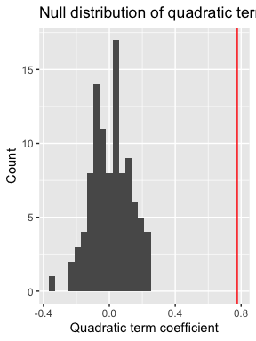

```r
quadratic_coefs <- parametric_boot_distribution(nonlinear_fit, quadratic_fit,
                                                data = nonlinear_data) |>
  filter(term == "I(x1^2)")

ggplot(quadratic_coefs, aes(x = estimate)) +
  geom_histogram() +
  geom_vline(xintercept = coef(quadratic_fit)["I(x1^2)"],
             color = "red") +
  labs(x = "Quadratic term coefficient",
       y = "Count",
       title = "Null distribution of quadratic term")
```

We see the quadratic coefficient estimated on the original data (vertical red line) is far larger than any of the quadratic coefficients estimated when the null is true, leading us to reject the null hypothesis that the quadratic coefficient is zero.